# Project 1

Shiyue Mao

1/9/2021

## Loading and preprocessing the data

Load data to R.

```r
library(readr)
activity <- read_csv("activity.csv")
```

## Mean total number of steps per day

A quick glance at the dataset and the first 6 observations.

```r
summary(activity)
```

```
##      steps             date               interval
##  Min.   :  0.00   Min.   :2012-10-01   Min.   :   0.0
##  1st Qu.:  0.00   1st Qu.:2012-10-16   1st Qu.: 588.8
##  Median :  0.00   Median :2012-10-31   Median :1177.5
##  Mean   : 37.38   Mean   :2012-10-31   Mean   :1177.5
##  3rd Qu.: 12.00   3rd Qu.:2012-11-15   3rd Qu.:1766.2
##  Max.   :806.00   Max.   :2012-11-30   Max.   :2355.0
##  NA's   :2304
```

```r
head(activity)
```

```
## # A tibble: 6 x 3
##   steps date       interval
##   <dbl> <date>        <dbl>
## 1    NA 2012-10-01        0
## 2    NA 2012-10-01        5
## 3    NA 2012-10-01       10
## 4    NA 2012-10-01       15
## 5    NA 2012-10-01       20
## 6    NA 2012-10-01       25
```

Calculate the total number of steps by introducing a new library dplyr, and then plot a histogram about it. After that, also show mean and median number for total steps per day.

```r
library(dplyr)
step_by_date <- aggregate(steps~date, data = activity, FUN = sum, na.rm = TRUE)
colnames(step_by_date) <- c("date", "total_steps")
# show total steps
step_by_date
```

```
##          date total_steps
## 1  2012-10-02         126
## 2  2012-10-03       11352
## 3  2012-10-04       12116
## 4  2012-10-05       13294
## 5  2012-10-06       15420
## 6  2012-10-07       11015
## 7  2012-10-09       12811
## 8  2012-10-10        9900
## 9  2012-10-11       10304
## 10 2012-10-12       17382
## 11 2012-10-13       12426
## 12 2012-10-14       15098
## 13 2012-10-15       10139
## 14 2012-10-16       15084
```

[output cut: 39 more lines]

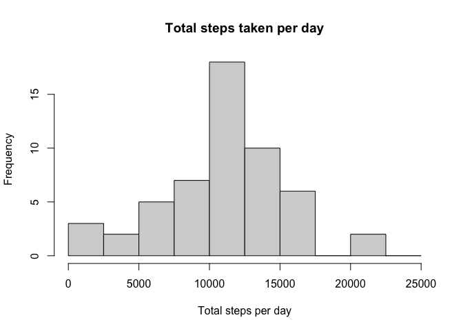

```r
# make a histogram plot
hist(step_by_date$total_steps, breaks = seq(0,25000, by = 2500), xlab = "Total steps per day", main = "Total steps taken per day")
```

```r
# take a look for mean and median value of the statistics
paste("The mean is ", mean(step_by_date$total_steps))
```

```
## [1] "The mean is  10766.1886792453"
```

```r
paste("The median is ",median(step_by_date$total_steps))
```

```
## [1] "The median is  10765"
```

## Average daily activity pattern

Firstly, make a time series plot with 5 min interval and average steps taken each day throughout the whole period.

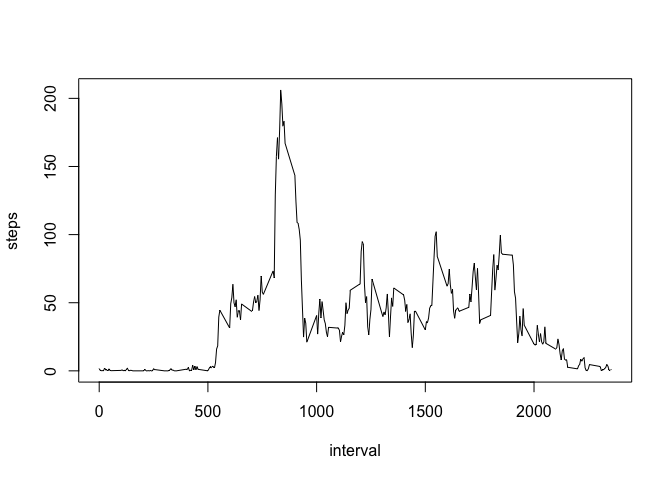

```r
avg_activity <- aggregate(activity$steps, by = list(activity$interval), FUN = mean, na.rm = TRUE)
names(avg_activity) <- c("interval", "steps")
with(avg_activity, plot(steps~interval, type = "l"))
```

Then, figure out which 5 min interval contains the maximum number of steps.

```r
avg_activity[which.max(avg_activity$steps),]$interval
```

```
## [1] 835
```

## Input missing values

Firstly, search total number of missing values (NAs) in the dataset. It seems there are 2304 NAs in the dataset.

```r
sum(is.na(activity))
```

```
## [1] 2304
```

Secondly, filling the NAs by mean of 5 min interval, and create a new dataset named new_activity

```r
activity$steps[is.na(activity$steps)] <- avg_activity$steps
new_activity <- activity
```

Then, make a histogram again with mean and median values.

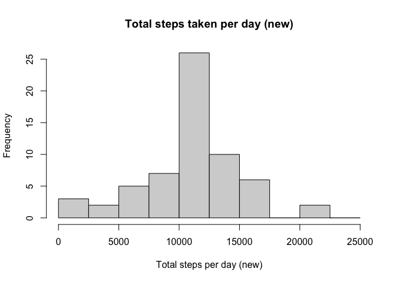

```r
new_step_by_date <- aggregate(steps~date, new_activity, FUN = sum)
colnames(new_step_by_date) <- c("date", "steps")
hist(new_step_by_date$steps, breaks = seq(0,25000, by = 2500), xlab = "Total steps per day (new)", main = "Total steps taken per day (new)")
```

```r
paste("The new mean is ", mean(new_step_by_date$steps))
```

```
## [1] "The new mean is  10766.1886792453"
```

```r
paste("The new median is ",median(new_step_by_date$steps))
```

```
## [1] "The new median is  10766.1886792453"
```

## Are there differences in activity patterns between weekdays and weekends?

Determine if the day is weekday or weekend.

```r
new_activity$weekday <- sapply(new_activity$date, function(x){
  if (weekdays(x) == "Saturday" | weekdays(x) == "Sunday")
      {y <- "Weekend"}
  else
      {y <- "Weekday"}
      y
})
```

make a new panel plot.

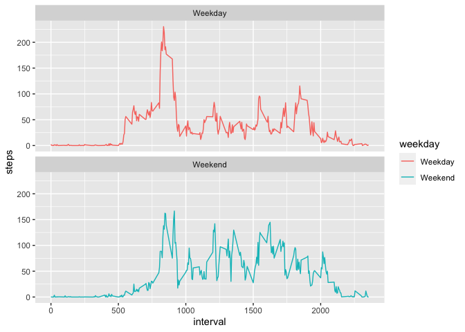

```r
library(ggplot2)
new_activity_by_date <- aggregate(steps~interval + weekday, data = new_activity, FUN = mean, na.rm = TRUE)
ggplot(new_activity_by_date, aes(x = interval, y = steps, colour = weekday)) +
  geom_line() +
  facet_wrap(~weekday, ncol = 1, nrow = 2)
```